# Threshold Selection: Using perch() and murmuration_plot()

Understanding, calibrating, and (when needed) manually reviewing the Fellegi-Sunter linkage cutoff

Dr Nicolas Smoll, SCPHU, Sunshine Coast Hospital and Health Service

2026-11-24

```r
library(starling)
library(mudnester)   # clean_the_nest() and the clutch_* datasets
library(dplyr)
library(ggplot2)

aviary_cols <- c(satin = "#325D88", chestnut = "#86251C", wattle = "#D8A31A",
                 evergreen = "#08403B", mud = "#A67D4C", slate = "#3E3F3A")
```

## (*)> Why the threshold matters

In the Fellegi-Sunter probabilistic linkage framework [1], every candidate pair of records receives a composite log-likelihood ratio score. Pairs scoring above a chosen threshold are classified as matches; those below are classified as non-matches. This threshold is **dataset-specific** – there is no universal correct value, because the score scale depends entirely on which variables are compared, their quality, and the composition of the two datasets being linked.

Choosing the threshold too low increases recall (more true matches recovered) at the cost of precision (more false matches accepted). Choosing it too high does the reverse. The optimal value sits in the **valley between the bimodal score distribution** – the gap between the non-match cluster at low scores and the match cluster at high scores.

`starling` provides two complementary tools for choosing that value, plus a way to review individual pairs when the distribution-level view isn’t enough:

- **`murmuration_plot()`** – shows the full weight distribution visually so you can see where the valley is
- **`perch()`** – quantifies match count, link rate, and clerical burden at each candidate cutoff, annotated with AIHW, WA Data Linkage Unit, and PHRN reference benchmarks
- **`murmuration(inspect_matches = TRUE)`** – for the less common case where a single blanket cutoff isn’t enough and specific pairs need a human eye (see Reviewing individual pairs below)

## (*)> Australian linkage authority benchmarks

The three key Australian and international reference points:

| Threshold range | Authority | Basis |
| --- | --- | --- |
| **10–20 (clerical zone)** | AIHW / WA Data Linkage Unit (WADLU) | Standard two-threshold practice: confirmed matches above about 20, confirmed non-matches below about 10, marginal pairs sent for human adjudication |
| **About 15–20** | Population Health Research Network (PHRN) | Operational target: false-match rate < 0.5% with a full variable set (Medicare + 2 names + DOB) |
| **16** | starling default | Calibrated on SCPHU linkages with 5 comparison variables (first name, last name, DOB, Medicare, and gender or postcode) where the Medicare number is present and current on both records |

These are reference points, not rules. The correct threshold for your dataset is the one that sits in the valley of *your* score distribution – and, as the worked example below shows, it can sit a long way from any of them. The section How many comparison variables? measures what the default recovers with 3, 4 and 5 variables.

## (*)> The worked example

The pairs come from a real linkage problem rather than a simulation: the `clutch_cases` notification linelist linked to the `clutch_air` immunisation register extract, both shipped in `mudnester`. They are synthetic people, but the identifier errors are realistic (typos, nicknames, swapped day and month, Medicare missing on about one notification in seven, households sharing a Medicare card). Each record carries a `truth_id`, so every threshold can be graded – something only a synthetic dataset allows. A threshold chosen from the score distribution rather than assumed is also how real studies handle records with identifier errors: an infant immunisation coverage study resolved about one birth-register record in ten that way [3]. Cleaning follows `vignette("pre-linkage-quality")`:

```r
cases_clean <- clutch_cases |>
  mutate(onset_imputed = is.na(onset_date),
         onset_date    = coalesce(onset_date, specimen_date)) |>
  clean_the_nest(
    data_type = "cases", drop_eggs = TRUE,
    id_var = "notification_id", diagnosis = "condition",
    lettername1 = "first_name", lettername2 = "surname", dob = "date_of_birth",
    gender = "sex", postcode = "postcode", medicare = "medicare_number",
    onset_date = "onset_date", keep_vars = c("truth_id", "onset_imputed")
  )
```

> **(*)> One vaccine type at a time.** For a vaccine question, filter the AIR extract to the vaccine you are studying before `clean_the_nest(lie_nest_flat = TRUE)` and `murmuration()` – otherwise `vax_date_1`, `vax_date_2`, … interleave every vaccine the person has had, and the dose counts and `vaccination_status` mean “any vaccine”. This vignette grades *identity* links, so it deliberately keeps every AIR person with a recorded vaccine of any type: that gives every notification the best chance of having a true record to find. Its event-window outputs (in Reviewing individual pairs) are therefore “any vaccine” and are only used to count links.

```r
air_clean <- clutch_air |>   # all antigens: every AIR person, for grading identity links
  clean_the_nest(
    data_type = "vaccination", lie_nest_flat = TRUE, drop_eggs = TRUE,
    id_var = "air_id", lettername1 = "given_name", lettername2 = "family_name",
    dob = "date_of_birth", gender = "sex", postcode = "postcode",
    medicare = "medicare_card", medicare_irn = "medicare_irn",
    vax_type = "antigen", vax_date = "date_of_service", keep_vars = "truth_id"
  )

# Invalid Medicare numbers become NA in both comparison fields, then
# block1: gender + birth year (used throughout); block2: birth year alone,
# for the comparison that scores gender instead of blocking on it
cases_blocked <- cases_clean |>
  check_medicare(verbose = FALSE) |>
  mutate(medicare10 = if_else(medicare_valid %in% 0L, NA_character_, medicare10),
         medicare09 = if_else(medicare_valid %in% 0L, NA_character_, medicare09)) |>
  flock(block1_vars = c("gender", "birth_year"), block2_vars = "birth_year",
        birth_year_col = "dob")

air_blocked <- air_clean |>
  check_medicare(verbose = FALSE) |>
  mutate(medicare10 = if_else(medicare_valid %in% 0L, NA_character_, medicare10),
         medicare09 = if_else(medicare_valid %in% 0L, NA_character_, medicare09)) |>
  flock(block1_vars = c("gender", "birth_year"), block2_vars = "birth_year",
        birth_year_col = "dob")

n_true <- cases_blocked |>
  filter(truth_id %in% air_blocked$truth_id) |>
  nrow()
c(cases = nrow(cases_blocked), air_people = nrow(air_blocked),
  cases_with_a_true_air_record = n_true)
```

```
#>                        cases                   air_people
#>                         3182                        10326
#> cases_with_a_true_air_record
#>                         2780
```

## (*)> Scoring every candidate pair once

`murmuration(inspect_matches = TRUE)` stops straight after blocking and EM scoring (run through `reclin2` [2]) and returns every candidate pair – not only those above the threshold – with the comparison fields from both sides joined in. `inspect_extra_vars` joins in context that is not scored: `truth_id` (the grading column) and `medicare_irn`, the 11th Medicare digit, used in Reviewing individual pairs. Nothing is decided yet, so every threshold below can be explored from this one object without re-fitting.

```r
review_4 <- murmuration(
  data_x             = cases_blocked,   # every notification
  data_y             = air_blocked,     # every AIR person
  linkage_type       = "cohort2event",
  event_type         = "vaccination",
  id_var             = "id_var",
  blocking_var       = "block1",        # gender + birth year
  compare_vars       = c("lettername1", "lettername2", "dob", "medicare10"),
  threshold_value    = 8,               # only marks the pairs; nothing is decided yet
  inspect_matches    = TRUE,            # stop after scoring; event_date not needed
  inspect_extra_vars = c("truth_id", "medicare09", "medicare_irn")  # context, not scored
)

medicare_levels <- c("Same Medicare number",
                     "Same account, card issue digit differs",
                     "Different Medicare number",
                     "Medicare missing on one or both records")

review_4 <- review_4 |>
  mutate(
    pair_type = if_else(truth_id.x == truth_id.y, "True match", "Non-match"),
    medicare_status = case_when(
      is.na(medicare10.x) | is.na(medicare10.y) ~ medicare_levels[4],
      medicare10.x == medicare10.y              ~ medicare_levels[1],
      medicare09.x == medicare09.y              ~ medicare_levels[2],
      TRUE                                      ~ medicare_levels[3]
    ),
    medicare_status = factor(medicare_status, levels = medicare_levels)
  )

c(candidate_pairs = nrow(review_4),
  true_pairs      = sum(review_4$pair_type == "True match"),
  max_weight      = round(max(review_4$weights), 2))
```

```
#> candidate_pairs      true_pairs      max_weight
#>       182240.00         2716.00           19.46
```

## (*)> Running `perch()` on the scored pairs

```r
sweep_4 <- perch(review_4,
                 n_records_primary = nrow(cases_blocked),
                 thresholds        = seq(4, 20, by = 1),
                 report            = FALSE,
                 plot              = FALSE)

sweep_4 |>
  select(threshold, n_above, pct_above, n_clerical, link_rate, reference) |>
  knitr::kable(caption = "Accepted pairs and clerical burden by threshold (4 comparison variables)")
```

Accepted pairs and clerical burden by threshold (4 comparison variables)

| threshold | n_above | pct_above | n_clerical | link_rate | reference |
| --- | --- | --- | --- | --- | --- |
| 4 | 8357 | 4.59 | 86540 | 2.6263 | NA |
| 5 | 6232 | 3.42 | 28033 | 1.9585 | NA |
| 6 | 3589 | 1.97 | 7949 | 1.1279 | NA |
| 7 | 2852 | 1.56 | 5697 | 0.8963 | NA |
| 8 | 2809 | 1.54 | 4061 | 0.8828 | NA |
| 9 | 2749 | 1.51 | 1447 | 0.8639 | NA |
| 10 | 2660 | 1.46 | 1067 | 0.8360 | AIHW/WADLU: lower bound of clerical review zone |
| 11 | 2171 | 1.19 | 1026 | 0.6823 | NA |
| 12 | 2142 | 1.18 | 975 | 0.6732 | NA |
| 13 | 1785 | 0.98 | 900 | 0.5610 | NA |
| 14 | 1783 | 0.98 | 454 | 0.5603 | NA |
| 15 | 1774 | 0.97 | 555 | 0.5575 | PHRN: lower bound for <0.5% false-match rate (full variable set) |
| 16 | 1760 | 0.97 | 270 | 0.5531 | starling default (balanced: Medicare + 2 names + DOB) |
| 17 | 1717 | 0.94 | 1783 | 0.5396 | NA |
| 18 | 1587 | 0.87 | 1774 | 0.4987 | NA |
| 19 | 1515 | 0.83 | 1760 | 0.4761 | NA |
| 20 | 0 | 0.00 | 1717 | 0.0000 | AIHW/WADLU: upper bound of clerical zone / confirmed matches above |

```r
clerical_8  <- sweep_4 |> filter(threshold == 8)  |> pull(n_clerical)
clerical_16 <- sweep_4 |> filter(threshold == 16) |> pull(n_clerical)
```

With `report = TRUE` (the default) the same table is printed with `[*]` markers on the four reference thresholds. With `plot = TRUE` the sweep is drawn, the AIHW/WADLU clerical zone shaded:

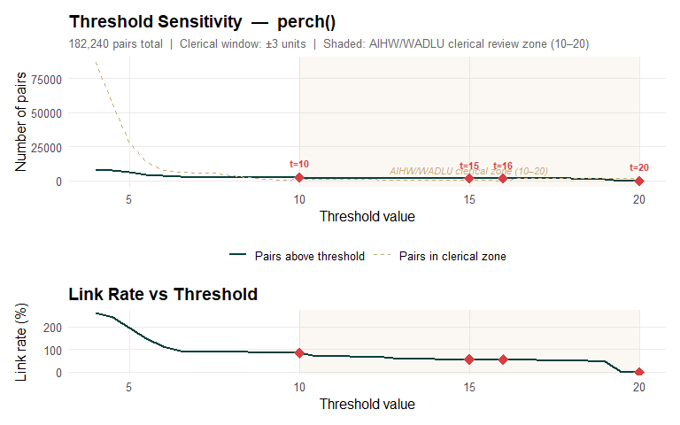

```r
perch(review_4,
      n_records_primary = nrow(cases_blocked),
      thresholds        = seq(4, 20, by = 0.5),
      report            = FALSE)
```

The accepted count is nearly flat between about 7 and 10 and then drops in steps. A flat stretch is what a valley looks like in this view: moving the threshold through it changes almost nothing.

## (*)> Visualising the score distribution

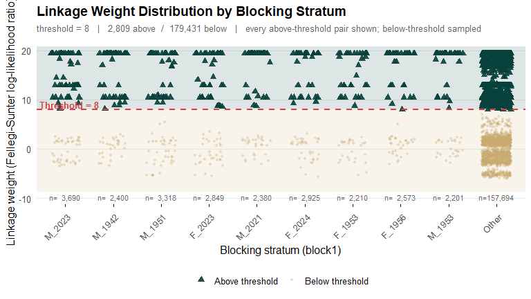

Candidate-pair weights by blocking stratum (gender + birth year; the busiest strata shown, the rest pooled), with the threshold at 8.

```r
murmuration_plot(review_4, max_levels = 10, palette = "sch")
```

Splitting the same weights by what happened to the Medicare number shows *why* the valley sits so low. The tenth digit is the card *issue* number, which changes every time a card is replaced, so the same person can carry several 10-digit numbers over a lifetime:

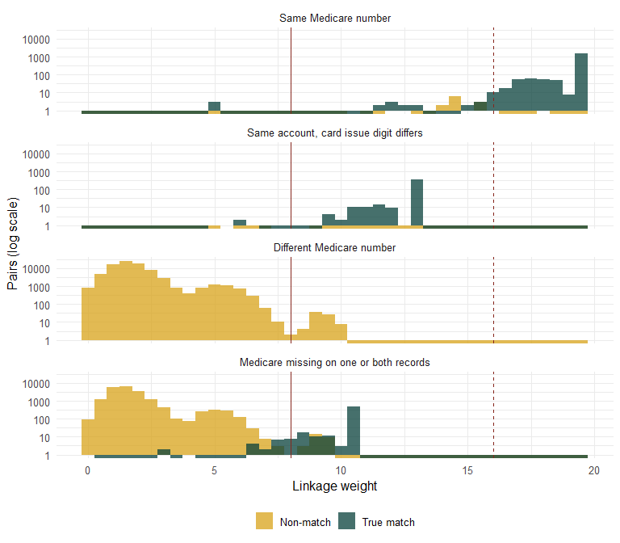

Weights of true matches and non-matches, by Medicare agreement. Solid line: threshold 8; dashed line: the default 16. Counts on a log scale.

```r
review_4 |>
  as.data.frame() |>
  filter(weights > 0) |>
  ggplot(aes(x = weights, fill = pair_type)) +
  geom_histogram(binwidth = 0.5, position = "identity", alpha = 0.75) +
  geom_vline(xintercept = 8, colour = aviary_cols[["chestnut"]]) +
  geom_vline(xintercept = 16, linetype = "dashed", colour = aviary_cols[["chestnut"]]) +
  scale_y_log10() +
  scale_fill_manual(values = c("True match" = aviary_cols[["evergreen"]],
                               "Non-match" = aviary_cols[["wattle"]])) +
  facet_wrap(~ medicare_status, ncol = 1) +
  labs(x = "Linkage weight", y = "Pairs (log scale)", fill = NULL) +
  theme_minimal(base_size = 12) +
  theme(legend.position = "bottom")
```

```r
review_4 |>
  as.data.frame() |>
  mutate(is_true = pair_type == "True match") |>
  group_by(medicare_status, .drop = FALSE) |>
  summarise(
    true_pairs        = sum(is_true),
    true_median_wt    = round(median(weights[is_true]), 1),
    true_5th_pct_wt   = round(unname(quantile(weights[is_true], 0.05)), 1),
    true_ge_16_pct    = round(100 * mean(weights[is_true] >= 16), 1),
    non_matches_ge_8  = sum(!is_true & weights >= 8),
    non_matches_ge_12 = sum(!is_true & weights >= 12)
  ) |>
  knitr::kable(caption = "Three clusters of true matches (NA: no pairs in that group)")
```

Three clusters of true matches (NA: no pairs in that group)

| medicare_status | true_pairs | true_median_wt | true_5th_pct_wt | true_ge_16_pct | non_matches_ge_8 | non_matches_ge_12 |
| --- | --- | --- | --- | --- | --- | --- |
| Same Medicare number | 1782 | 19.5 | 17.1 | 98.7 | 17 | 16 |
| Same account, card issue digit differs | 404 | 12.9 | 10.7 | 0.0 | 2 | 0 |
| Different Medicare number | 0 | NA | NA | NaN | 78 | 0 |
| Medicare missing on one or both records | 530 | 10.5 | 8.3 | 0.0 | 26 | 0 |

There are three match clusters, not one. When all four fields agree the weight is close to the maximum. When the card has been reissued between the two records the Medicare comparison only partly agrees and the true pair drops to about 13; when Medicare is missing on one side it can score no more than the name and date-of-birth weights, around 10. The default of 16 sits under nearly all of the upper cluster and above both lower ones: it does not sit between matches and non-matches at all, but between *Medicare agrees* and *everything else*. The handful of non-matches above 12 are mostly family members who share a Medicare card and a birth year; below 12 they are joined by people with common names born in the same year.

A well-behaved distribution is clearly bimodal. If yours is not:

- **Unimodal at low scores**: almost all pairs are non-matches. Check that your blocking variable is not too restrictive, excluding true match candidates from ever being compared.
- **Unimodal at high scores**: unusual. Suggests a highly specific blocking variable that only passes near-certain matches.
- **Flat / no clear valley**: the comparison variables may lack discriminating power. Review `preflight()` output for high missingness or poor name quality.
- **Several match clusters, as here**: one comparison field is often missing. Choose the valley below the *lowest* match cluster you want to keep.

## (*)> Grading thresholds against the truth

With ground truth available, each threshold can be scored directly: keep the highest-weighted candidate per case among pairs at or above the threshold, then count how many are the right person.

```r
# The highest-weighted candidate per case is the link at every threshold it
# clears, so grading a threshold is just counting top candidates above it.
top_4 <- review_4 |>
  as.data.frame() |>
  arrange(desc(weights)) |>
  distinct(id_var.x, .keep_all = TRUE) |>
  transmute(id_var.x, weights, correct = truth_id.x == truth_id.y)

grade_4 <- tibble(threshold = seq(5, 18, by = 0.5)) |>
  cross_join(top_4) |>
  filter(weights >= threshold) |>
  group_by(threshold) |>
  summarise(links = n(), correct = sum(correct)) |>
  mutate(precision = correct / links,
         recall    = correct / n_true,
         f1        = 2 * precision * recall / (precision + recall))

best_4    <- grade_4 |> slice_max(f1, n = 1, with_ties = FALSE) |> pull(threshold)
at_best_4 <- grade_4 |> filter(threshold == best_4)
at_16_4   <- grade_4 |> filter(threshold == 16)

grade_4 |>
  filter(threshold %in% c(5, 6, 7, 7.5, 8, 9, 10, 11, 12, 14, 16, 17)) |>
  knitr::kable(digits = 3,
               caption = "Precision, recall and F1 by threshold (4 comparison variables)")
```

Precision, recall and F1 by threshold (4 comparison variables)

| threshold | links | correct | precision | recall | f1 |
| --- | --- | --- | --- | --- | --- |
| 5.0 | 2940 | 2710 | 0.922 | 0.975 | 0.948 |
| 6.0 | 2790 | 2704 | 0.969 | 0.973 | 0.971 |
| 7.0 | 2707 | 2696 | 0.996 | 0.970 | 0.983 |
| 7.5 | 2702 | 2695 | 0.997 | 0.969 | 0.983 |
| 8.0 | 2693 | 2686 | 0.997 | 0.966 | 0.982 |
| 9.0 | 2664 | 2660 | 0.998 | 0.957 | 0.977 |
| 10.0 | 2641 | 2639 | 0.999 | 0.949 | 0.974 |
| 11.0 | 2156 | 2155 | 1.000 | 0.775 | 0.873 |
| 12.0 | 2127 | 2126 | 1.000 | 0.765 | 0.867 |
| 14.0 | 1771 | 1770 | 0.999 | 0.637 | 0.778 |
| 16.0 | 1758 | 1758 | 1.000 | 0.632 | 0.775 |
| 17.0 | 1716 | 1716 | 1.000 | 0.617 | 0.763 |

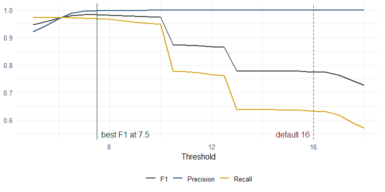

```r
grade_long <- bind_rows(
  grade_4 |> transmute(threshold, measure = "Precision", value = precision),
  grade_4 |> transmute(threshold, measure = "Recall",    value = recall),
  grade_4 |> transmute(threshold, measure = "F1",        value = f1)
)

ggplot(grade_long, aes(x = threshold, y = value, colour = measure)) +
  geom_line(linewidth = 1) +
  geom_vline(xintercept = best_4, colour = aviary_cols[["evergreen"]]) +
  geom_vline(xintercept = 16, colour = aviary_cols[["chestnut"]], linetype = "dashed") +
  annotate("text", x = best_4, y = 0.55, label = paste("best F1 at", best_4),
           hjust = -0.1, colour = aviary_cols[["evergreen"]]) +
  annotate("text", x = 16, y = 0.55, label = "default 16", hjust = 1.1,
           colour = aviary_cols[["chestnut"]]) +
  scale_colour_manual(values = c(Precision = aviary_cols[["satin"]],
                                 Recall = aviary_cols[["wattle"]],
                                 F1 = aviary_cols[["slate"]])) +
  labs(x = "Threshold", y = NULL, colour = NULL) +
  theme_minimal(base_size = 12) +
  theme(legend.position = "bottom")
```

F1 peaks at 7.5, with precision 99.7% and recall 96.9%. At the default 16 precision is essentially perfect but recall falls to 63.2%: of the people who *are* in the register, 37% would be classed as unvaccinated, which biases any vaccine effectiveness estimate built on the linkage. In production there is no truth column, but the valley in `murmuration_plot()` and the flat stretch in `perch()` point to the same place.

## (*)> How many comparison variables? {#how-many-comparison-variables}

The default `threshold_value = 16` is calibrated for five comparison variables – first name, last name, date of birth, Medicare number, and gender or postcode – with a Medicare number that agrees on both records. Every variable added raises the ceiling of the weight scale, so a threshold only means something next to the variable set it was chosen for. To measure how much that matters, the same cases are scored against the same register six ways, one `murmuration()` call each. `threshold_value` is left at its default, so each table’s `threshold` column already marks the pairs at or above 16.

| Set | Comparison variables | Blocking |
| --- | --- | --- |
| 3 | `lettername1`, `lettername2`, `dob` | gender + birth year (`block1`) |
| 4 | + `medicare10` (`review_4` above) | gender + birth year |
| 4 | + `medicare09` | gender + birth year |
| 5 | + `medicare10` + `postcode` | gender + birth year |
| 5 | + `medicare09` + `postcode` | gender + birth year |
| 5 | + `medicare10` + `gender` | birth year only (`block2`) |

Gender cannot be the fifth variable inside a gender block: it agrees on every pair there, so it carries no weight. Scoring it means blocking on birth year alone. The three-variable set is the probabilistic counterpart of the exact first name, last name and date-of-birth key used by a regional Queensland COVID-19 vaccine effectiveness linkage study [4].

```r
# threshold_value is left at its default (16) in every call
review_3 <- murmuration(
  data_x             = cases_blocked,
  data_y             = air_blocked,
  linkage_type       = "cohort2event",
  event_type         = "vaccination",
  id_var             = "id_var",
  blocking_var       = "block1",       # gender + birth year
  compare_vars       = c("lettername1", "lettername2", "dob"),
  inspect_matches    = TRUE,           # score only
  inspect_extra_vars = "truth_id"      # for grading
)
review_4_m09 <- murmuration(
  data_x             = cases_blocked,
  data_y             = air_blocked,
  linkage_type       = "cohort2event",
  event_type         = "vaccination",
  id_var             = "id_var",
  blocking_var       = "block1",
  compare_vars       = c("lettername1", "lettername2", "dob", "medicare09"),
  inspect_matches    = TRUE,
  inspect_extra_vars = "truth_id"
)
review_5_pc <- murmuration(
  data_x             = cases_blocked,
  data_y             = air_blocked,
  linkage_type       = "cohort2event",
  event_type         = "vaccination",
  id_var             = "id_var",
  blocking_var       = "block1",
  compare_vars       = c("lettername1", "lettername2", "dob", "medicare10", "postcode"),
  inspect_matches    = TRUE,
  inspect_extra_vars = c("truth_id", "medicare09")
)
review_5_m09 <- murmuration(
  data_x             = cases_blocked,
  data_y             = air_blocked,
  linkage_type       = "cohort2event",
  event_type         = "vaccination",
  id_var             = "id_var",
  blocking_var       = "block1",
  compare_vars       = c("lettername1", "lettername2", "dob", "medicare09", "postcode"),
  inspect_matches    = TRUE,
  inspect_extra_vars = c("truth_id", "medicare10")
)
review_5_sex <- murmuration(
  data_x             = cases_blocked,
  data_y             = air_blocked,
  linkage_type       = "cohort2event",
  event_type         = "vaccination",
  id_var             = "id_var",
  blocking_var       = "block2",       # birth year only
  compare_vars       = c("lettername1", "lettername2", "dob", "medicare10", "gender"),
  inspect_matches    = TRUE,
  inspect_extra_vars = "truth_id"
)
```

Each set is graded exactly as before: at every threshold, keep the highest-weighted candidate per case and count how many are the right person.

```r
set_names <- c("3: names + DOB",
               "4: + medicare10",
               "4: + medicare09",
               "5: + medicare10 + postcode",
               "5: + medicare09 + postcode",
               "5: + medicare10 + gender (year blocks)")

# every scored pair from the six runs, labelled by variable set
all_pairs <- bind_rows(
  review_3     |> as.data.frame() |> mutate(variables = set_names[1]),
  review_4     |> as.data.frame() |> mutate(variables = set_names[2]),
  review_4_m09 |> as.data.frame() |> mutate(variables = set_names[3]),
  review_5_pc  |> as.data.frame() |> mutate(variables = set_names[4]),
  review_5_m09 |> as.data.frame() |> mutate(variables = set_names[5]),
  review_5_sex |> as.data.frame() |> mutate(variables = set_names[6])
) |>
  select(variables, id_var.x, truth_id.x, truth_id.y, weights) |>
  mutate(variables = factor(variables, levels = set_names))

set_sizes <- all_pairs |>
  group_by(variables) |>
  summarise(candidate_pairs = n(), max_weight = round(max(weights), 1))

# the top candidate per case, in each set
top_pairs <- all_pairs |>
  arrange(desc(weights)) |>
  distinct(variables, id_var.x, .keep_all = TRUE) |>
  mutate(correct = truth_id.x == truth_id.y)

thresholds <- tibble(threshold = seq(2, 24, by = 0.5))

curves <- top_pairs |>
  cross_join(thresholds) |>
  filter(weights >= threshold) |>
  group_by(variables, threshold) |>
  summarise(links = n(), correct = sum(correct), .groups = "drop") |>
  right_join(cross_join(tibble(variables = factor(set_names, levels = set_names)), thresholds),
             by = c("variables", "threshold")) |>
  mutate(links     = coalesce(links, 0L),       # no pair above this threshold
         correct   = coalesce(correct, 0L),
         precision = if_else(links > 0, correct / links, NA_real_),
         recall    = correct / n_true,
         f1        = 2 * precision * recall / (precision + recall)) |>
  arrange(variables, threshold)

best_by_set <- curves |>
  filter(!is.na(f1)) |>
  group_by(variables) |>
  slice_max(f1, n = 1, with_ties = FALSE) |>
  ungroup() |>
  transmute(variables,
            best_f1_threshold = threshold,
            recall_at_best    = round(100 * recall, 1),
            precision_at_best = round(100 * precision, 1))

nvars_table <- set_sizes |>
  left_join(curves |>
              filter(threshold == 16) |>
              transmute(variables,
                        recall_at_16    = round(100 * recall, 1),
                        precision_at_16 = round(100 * precision, 1)),
            by = "variables") |>
  left_join(curves |>
              filter(threshold == 17) |>
              transmute(variables, recall_at_17 = round(100 * recall, 1)),
            by = "variables") |>
  left_join(best_by_set, by = "variables") |>
  arrange(variables)

knitr::kable(nvars_table, format.args = list(big.mark = ","),
             caption = "Recall and precision (%) at 16 and 17, and at each set's best-F1 threshold")
```

Recall and precision (%) at 16 and 17, and at each set’s best-F1 threshold

| variables | candidate_pairs | max_weight | recall_at_16 | precision_at_16 | recall_at_17 | best_f1_threshold | recall_at_best | precision_at_best |
| --- | --- | --- | --- | --- | --- | --- | --- | --- |
| 3: names + DOB | 182,240 | 10.5 | 0.0 | NA | 0.0 | 6.5 | 96.7 | 99.5 |
| 4: + medicare10 | 182,240 | 19.5 | 63.2 | 100.0 | 61.7 | 7.5 | 96.9 | 99.7 |
| 4: + medicare09 | 182,240 | 19.5 | 77.4 | 100.0 | 75.6 | 7.5 | 97.1 | 99.7 |
| 5: + medicare10 + postcode | 182,240 | 21.8 | 63.6 | 99.9 | 63.6 | 8.5 | 97.2 | 99.6 |
| 5: + medicare09 + postcode | 182,240 | 21.8 | 77.9 | 100.0 | 77.9 | 8.5 | 97.3 | 99.7 |
| 5: + medicare10 + gender (year blocks) | 365,595 | 19.2 | 61.8 | 100.0 | 58.6 | 8.0 | 97.6 | 99.1 |

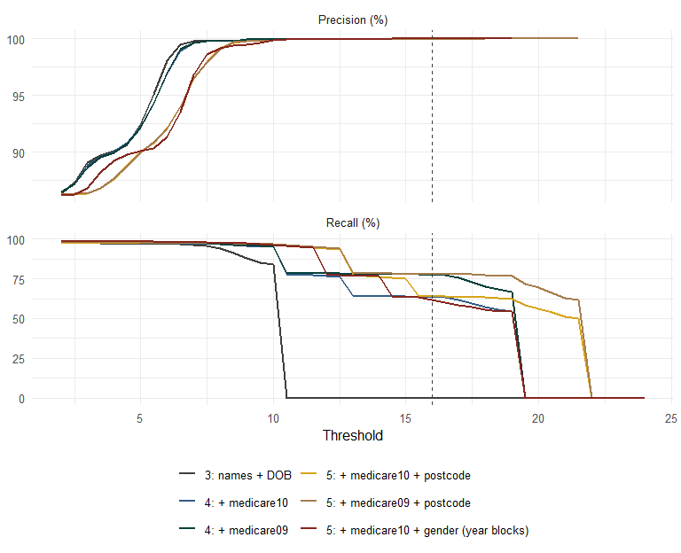

Recall and precision by threshold for each comparison-variable set, keeping the best-weighted candidate per case. Dashed line: the default 16.

```r
curves_long <- bind_rows(
  curves |> transmute(variables, threshold, measure = "Recall (%)",    value = 100 * recall),
  curves |> transmute(variables, threshold, measure = "Precision (%)", value = 100 * precision)
) |>
  filter(!is.na(value))

ggplot(curves_long, aes(x = threshold, y = value, colour = variables)) +
  geom_line(linewidth = 0.9) +
  geom_vline(xintercept = 16, linetype = "dashed", colour = aviary_cols[["slate"]]) +
  facet_wrap(~ measure, ncol = 1, scales = "free_y") +
  scale_colour_manual(values = unname(aviary_cols[c("slate", "satin", "evergreen",
                                                    "wattle", "mud", "chestnut")])) +
  labs(x = "Threshold", y = NULL, colour = NULL) +
  theme_minimal(base_size = 12) +
  theme(legend.position = "bottom") +
  guides(colour = guide_legend(ncol = 2))
```

Reading across the 16 column:

- **Three variables**: no pair can reach 16 – the highest weight is 10.5. A full `murmuration()` run at the default would report `Pairs selected (threshold=TRUE): 0`, and that message means exactly this: the threshold, not the data, is the problem.
- **Four variables with `medicare10`**: the ceiling rises to 19.5, yet recall at 16 is 63.2%.
- **A fifth variable barely moves it**: 63.6% with postcode, and 61.8% with gender scored instead of blocked – at 2 times the candidate pairs.
- **`medicare09` instead of `medicare10`** lifts recall at 16 to 77.4% with four variables and 77.9% with five.
- **At its own best-F1 threshold**, every set that includes Medicare recovers 96.9–97.6% of true pairs at 99.1% precision or better, with best thresholds between 7.5 and 8.5.

Why does a five-variable linkage, the kind 16 was calibrated for, still miss 36% of the true pairs at 16? Splitting its true pairs by what happened to the Medicare number answers that:

```r
# the true pairs of the two five-variable (postcode) runs, by Medicare agreement
true_5 <- bind_rows(
  review_5_pc  |> as.data.frame() |> mutate(medicare_field = "medicare10"),
  review_5_m09 |> as.data.frame() |> mutate(medicare_field = "medicare09")
) |>
  filter(truth_id.x == truth_id.y) |>
  mutate(
    medicare_status = case_when(
      is.na(medicare10.x) | is.na(medicare10.y) ~ medicare_levels[4],
      medicare10.x == medicare10.y              ~ medicare_levels[1],
      medicare09.x == medicare09.y              ~ medicare_levels[2],
      TRUE                                      ~ medicare_levels[3]
    ),
    medicare_status = factor(medicare_status, levels = medicare_levels)
  )

by_status_10 <- true_5 |>
  filter(medicare_field == "medicare10") |>
  group_by(medicare_status, .drop = FALSE) |>
  summarise(true_pairs           = n(),
            median_wt_medicare10 = round(median(weights), 1),
            pct_ge_16_medicare10 = round(100 * mean(weights >= 16), 1))

by_status_09 <- true_5 |>
  filter(medicare_field == "medicare09") |>
  group_by(medicare_status, .drop = FALSE) |>
  summarise(median_wt_medicare09 = round(median(weights), 1),
            pct_ge_16_medicare09 = round(100 * mean(weights >= 16), 1))

medicare_by_field <- by_status_10 |>
  left_join(by_status_09, by = "medicare_status") |>
  mutate(pct_of_true_pairs = round(100 * true_pairs / sum(true_pairs)))

knitr::kable(medicare_by_field,
             caption = "True pairs by Medicare agreement: five variables (names, DOB, Medicare, postcode)")
```

True pairs by Medicare agreement: five variables (names, DOB, Medicare, postcode)

| medicare_status | true_pairs | median_wt_medicare10 | pct_ge_16_medicare10 | median_wt_medicare09 | pct_ge_16_medicare09 | pct_of_true_pairs |
| --- | --- | --- | --- | --- | --- | --- |
| Same Medicare number | 1782 | 21.8 | 99.3 | 21.8 | 99.3 | 66 |
| Same account, card issue digit differs | 404 | 15.2 | 0.0 | 21.8 | 98.3 | 15 |
| Different Medicare number | 0 | NA | NaN | NA | NaN | 0 |
| Medicare missing on one or both records | 530 | 12.8 | 0.0 | 12.8 | 0.0 | 20 |

```r
median_reissued <- medicare_by_field |> filter(medicare_status == medicare_levels[2]) |> pull(median_wt_medicare10)
median_missing  <- medicare_by_field |> filter(medicare_status == medicare_levels[4]) |> pull(median_wt_medicare10)
pct_agrees      <- medicare_by_field |> filter(medicare_status == medicare_levels[1]) |> pull(pct_of_true_pairs)
pct_reissued    <- medicare_by_field |> filter(medicare_status == medicare_levels[2]) |> pull(pct_of_true_pairs)
pct_missing     <- medicare_by_field |> filter(medicare_status == medicare_levels[4]) |> pull(pct_of_true_pairs)
```

So 16 is not failing at random. With five variables it keeps the true pairs whose Medicare number agrees and very little else. A reissued card costs a true pair enough weight to finish just below 16 (median 15.2 with `medicare10`), and a missing number costs more (median 12.8). In this linelist 20% of true pairs have Medicare missing on one side and a further 15% carry a different card issue digit, so recall at 16 is capped near 66% however many other fields agree. `medicare09` scores the reissued cards as agreeing and recovers that group; the Medicare-missing group stays out of reach at 16 whichever field is used.

That is what *calibrated for five variables with an agreeing Medicare number* means in practice. Where Medicare is complete and current on both sources, 16 sits safely inside the valley. On a notification linelist, where it often is not, 16 is a high-precision, low-recall choice, and the score distribution – not the default – has to set the threshold. Re-plot and re-choose whenever `compare_vars` changes, and whenever the completeness of the Medicare field does.

## (*)> Using `perch_before_linking = TRUE` inside `murmuration()`

For the common one-step workflow, set `perch_before_linking = TRUE` in the `murmuration()` call. The sensitivity table is printed immediately after the EM model fits – before the threshold is applied – giving you a chance to review before the linked dataset is produced.

```r
linked <- murmuration(
  data_x               = cases_blocked,
  data_y               = air_covid_blocked,  # for a vaccine question: ONE vaccine type
  linkage_type         = "cohort2event",
  event_type           = "vaccination",
  event_date           = "onset_date",
  id_var               = "id_var",
  blocking_var         = "block1",
  compare_vars         = c("lettername1", "lettername2", "dob", "medicare10"),
  threshold_value      = 8,
  perch_before_linking = TRUE,     # <-- prints the perch() table mid-linkage
  keep_pairs_pred      = TRUE      # <-- keeps the pairs for later re-exploration
)
```

In a Quarto document or batch job (`interactive() == FALSE`), the table is printed to the console but the plot is suppressed and execution continues automatically. In an interactive session, the plot is displayed.

If the table suggests a better threshold, there is no need to re-fit the EM model just to look. With `keep_pairs_pred = TRUE` the full scored-pairs table is attached to the result as `attr(linked, "pairs_pred")`, so both `murmuration_plot()` and `perch()` can be re-run against it:

```r
murmuration_plot(linked, threshold = 9)                     # a different cutoff
perch(attr(linked, "pairs_pred"), n_records_primary = nrow(cases_blocked),
      thresholds = seq(4, 20, by = 1))                       # re-sweep, no re-fit
```

Re-running `murmuration()` itself is only needed once you are ready to produce the final linked dataset under the new threshold – `threshold_value` controls which pairs `link()` actually keeps in the output.

## (*)> Clerical review zone

In a formal two-threshold design (AIHW/WADLU practice), pairs in a band around the cutoff are neither automatically accepted nor rejected – they are sent for human review. The `n_clerical` column in `perch()` output shows how many pairs fall in the review zone around each candidate threshold (default window: ±3 units). Here, a band of ±3 around 8 holds 4,061 pairs, while the same band around the default 16 holds 270.

A large `n_clerical` relative to `n_above` means the threshold sits in a high-density region – small threshold changes would reclassify many pairs. This is a signal that you are sitting on a slope, not in a valley. Read that way, the band around 8 looks crowded too, but for a different reason: on this compressed four-variable scale the default ±3 band is wider than the valley itself, reaching down into the non-match tail below 6 and up into the Medicare-missing cluster near 10. A narrower `clerical_window` (say 2) is the fairer test here.

## (*)> Reviewing individual pairs {#reviewing-individual-pairs}

`perch()` and `murmuration_plot()` describe the *distribution* of scores, not any individual pair. Two kinds of pair in this linkage deserve a closer look, and `review_4` already holds everything needed: the identifying fields from both sides, a mechanical `threshold` column (`weights >= 8`), and an empty `match_override` column (`NA`, `"match"` or `"non-match"`).

**Family members on one card.** A pair above the threshold where the Medicare number agrees but both the first name and the date of birth differ is the signature of a sibling or partner, not of the person. The IRN joined in by `inspect_extra_vars` – the 11th digit, the person’s position on the card – is shown alongside:

```r
review_4 <- review_4 |>
  mutate(
    # above the threshold, same card, but a different first name AND date of birth
    family_flag = threshold &
      (medicare10.x == medicare10.y) %in% TRUE &
      (dob.x != dob.y) %in% TRUE &
      (lettername1.x != lettername1.y) %in% TRUE,
    # ...and both records carry the IRN
    irn_known = family_flag & !is.na(medicare_irn.x) & !is.na(medicare_irn.y)
  )

n_family_flag <- sum(review_4$family_flag)
n_irn_known   <- sum(review_4$irn_known)

review_4 |>
  as.data.frame() |>
  filter(family_flag) |>
  select(lettername1.x, lettername1.y, lettername2.x, lettername2.y,
         dob.x, dob.y, medicare_irn.x, medicare_irn.y, weights) |>
  knitr::kable(digits = 1,
               caption = "Above-threshold pairs sharing a Medicare card but not a first name or DOB")
```

Above-threshold pairs sharing a Medicare card but not a first name or DOB

| lettername1.x | lettername1.y | lettername2.x | lettername2.y | dob.x | dob.y | medicare_irn.x | medicare_irn.y | weights |
| --- | --- | --- | --- | --- | --- | --- | --- | --- |
| maggie | margaret | thomas | thomas | 1952-02-13 | 1952-02-14 | 1 | 1 | 16.1 |
| sandra | deborah | nicholls | nicholls | 1968-04-01 | 1968-10-04 | NA | 2 | 15.5 |
| ruby | ava | robinson | robinson | 2022-01-06 | 2022-01-02 | NA | 3 | 12.7 |
| isabella | grace | smith | smith | 2022-09-03 | 2022-04-16 | NA | 3 | 14.6 |
| chloe | eleni | rossi | rossi | 2022-10-09 | 2022-07-05 | NA | 5 | 14.7 |
| eleni | chloe | rossi | rossi | 2022-07-05 | 2022-10-09 | 5 | 4 | 14.7 |
| ruby | willow | clark | clarke | 2023-07-19 | 2023-12-04 | NA | 3 | 10.4 |
| lily | mia | young | young | 2023-10-12 | 2023-11-11 | NA | 4 | 14.6 |
| aaliyah | evie | graham | graham | 2023-09-24 | 2023-12-15 | NA | 3 | 14.1 |
| robert | graham | watson | watson | 1943-08-02 | 1943-12-11 | 1 | 2 | 14.0 |
| scott | stephen | phillips | phillips | 1977-02-15 | 1977-02-25 | NA | 1 | 15.5 |
| archie | lachlan | kelly | kelly | 2016-02-22 | 2016-02-03 | NA | 4 | 15.3 |
| archie | noah | kelly | kelly | 2016-02-22 | 2016-01-24 | NA | 5 | 15.0 |
| aiden | jayden | dunn | dunn | 2018-07-11 | 2018-12-07 | NA | 3 | 16.1 |
| charlie | chkrlie | walker | walker | 2020-03-18 | 2020-03-08 | NA | 4 | 17.2 |
| tom | elijah | smith | smith | 2023-07-28 | 2023-10-22 | NA | 4 | 12.2 |
| noah | charlie | williams | williams | 2023-11-10 | 2023-07-11 | NA | 3 | 14.5 |
| noah | charlie | williams | williams | 2023-11-10 | 2023-07-11 | NA | 3 | 14.5 |

Where both records carry an IRN it settles the question: people on one card share the 10-digit number but never the IRN (see `vignette("pre-linkage-quality")`). Only notifications that recorded all 11 digits have one, so 3 of the 18 flagged pairs can be decided that way. For the rest, read down the list: most rows are clearly two different children or adults on one card, but a nickname or a single-letter typo can produce the same pattern for the right person – which is why the flag is a prompt for a human decision, not a rule to apply blindly. Record each decision in `match_override`; in this teaching dataset `truth_id` stands in for the reviewer’s judgement:

```r
review_plain <- review_4    # kept unchanged for comparison below

review_4 <- review_4 |>
  mutate(
    match_override = case_when(
      irn_known   ~ if_else(medicare_irn.x == medicare_irn.y, "match", "non-match"),
      family_flag ~ if_else(truth_id.x == truth_id.y, "match", "non-match"),  # the reviewer
      TRUE        ~ match_override
    ),
    override_reason = case_when(
      irn_known   ~ "Shared Medicare card: decided on the IRN",
      family_flag ~ "Shared Medicare card: reviewed for family member",
      TRUE        ~ NA_character_
    )
  )

review_4 |>
  as.data.frame() |>
  filter(!is.na(override_reason)) |>
  count(override_reason, match_override, name = "pairs") |>
  knitr::kable()
```

| override_reason | match_override | pairs |
| --- | --- | --- |
| Shared Medicare card: decided on the IRN | match | 1 |
| Shared Medicare card: decided on the IRN | non-match | 2 |
| Shared Medicare card: reviewed for family member | match | 1 |
| Shared Medicare card: reviewed for family member | non-match | 14 |

**Several candidates for one case.** When more than one candidate is accepted for the same case, `murmuration()` keeps the highest-weighted one. That is the right default, but in a reviewed table it means a reviewer’s `"match"` on a lower-weighted pair would still lose to a higher-weighted pair nobody looked at. An explicit, reproducible rule avoids that: keep the best accepted candidate per case – a reviewed match first, then the highest weight – and mark the others `"non-match"`.

```r
# accepted = a reviewed match, or above the threshold and not reviewed;
# rank within each case (reviewed match first, then weight) and keep the first
runner_up_rows <- review_4 |>
  as.data.frame() |>
  mutate(row = row_number()) |>
  filter(match_override %in% "match" | (is.na(match_override) & threshold)) |>
  arrange(id_var.x, desc(match_override %in% "match"), desc(weights)) |>
  filter(duplicated(id_var.x)) |>
  pull(row)

review_4 <- review_4 |>
  mutate(
    runner_up       = row_number() %in% runner_up_rows,
    match_override  = if_else(runner_up, "non-match", match_override),
    override_reason = if_else(runner_up, "Lower-ranked of several accepted candidates",
                              override_reason)
  )

c(cases_with_several_candidates = n_distinct(review_4$id_var.x[review_4$runner_up]),
  pairs_overridden = sum(!is.na(review_4$match_override)))
```

```
#> cases_with_several_candidates              pairs_overridden
#>                            99                           119
```

Finish the linkage by passing the reviewed table back in as `resume_from_pairs`. This applies the overrides, then runs exactly the same event-window logic a normal `murmuration()` call would. Passing the untouched copy instead reproduces the plain threshold-8 linkage without re-fitting anything:

```r
linked_plain <- murmuration(
  data_x            = cases_blocked,   # the SAME frames that built review_4
  data_y            = air_blocked,
  linkage_type      = "cohort2event",
  event_type        = "vaccination",
  event_date        = "onset_date",
  id_var            = "id_var",
  threshold_value   = 8,
  resume_from_pairs = review_plain     # no overrides: the plain threshold-8 linkage
)
linked_reviewed <- murmuration(
  data_x            = cases_blocked,
  data_y            = air_blocked,
  linkage_type      = "cohort2event",
  event_type        = "vaccination",
  event_date        = "onset_date",
  id_var            = "id_var",
  threshold_value   = 8,
  resume_from_pairs = review_4         # with the reviewer's decisions
)

# grade both against the truth
air_truth <- air_blocked |>
  select(id_var_y = id_var, truth_id_air = truth_id)

bind_rows(
  linked_plain    |> mutate(linkage = "Threshold 8, no review"),
  linked_reviewed |> mutate(linkage = "Threshold 8, reviewed")
) |>
  left_join(air_truth, by = "id_var_y") |>
  group_by(linkage) |>
  summarise(links   = sum(!is.na(truth_id_air)),
            correct = sum(truth_id_air == truth_id, na.rm = TRUE)) |>
  mutate(precision = round(100 * correct / links, 1)) |>
  knitr::kable(caption = "Precision (%) before and after review")
```

Precision (%) before and after review

| linkage | links | correct | precision |
| --- | --- | --- | --- |
| Threshold 8, no review | 2693 | 2686 | 99.7 |
| Threshold 8, reviewed | 2692 | 2686 | 99.8 |

`cases_blocked`/`air_blocked` must be the exact data frames used to build `review_4` – its `.x`/`.y` columns are row indices into them. `blocking_var` and `compare_vars` are not needed in this mode, since blocking and scoring have already happened. For a full worked review on a small, high-stakes linkage – measles contacts, where every individual decision matters – see `vignette("clinical-linkage-review")`.

## (*)> References

1. Fellegi IP, Sunter AB. A theory for record linkage. J Am Stat Assoc. 1969;64(328):1183–1210.
2. van der Laan DJ. reclin2: a toolkit for record linkage and deduplication. R J. 2022;14(2):320–328.
3. Roughan WH, Cavanagh-Ochiai B, Barnekow D, Lottkowitz K, Schafer K, Camadoo L, Smoll NR. Infant respiratory syncytial virus (RSV) immunisation coverage in an Australian regional area, 1 May 2024 – 31 October 2025. Commun Dis Intell. 2026;50. doi:10.33321/cdi.2026.50.031. **Applied**: about 10% of its birth-register records carried identifier or date-of-birth errors and were resolved with weighted-score matching, the situation in which a threshold has to be chosen from the score distribution rather than assumed.
4. Smoll NR, Al Imam MH, Shulz C, Booy R, Khandaker G. The effectiveness of vaccination for preventing hospitalisation with COVID-19 in regional Queensland: a data linkage study. Med J Aust. 2023;219(4):162–165. doi:10.5694/mja2.52019. **Precedent**: its exact three-field key (first name, last name, date of birth) is the deterministic counterpart of the three-variable linkage graded above.